# Question

Un investigador realizó un registro en un gimnasio para analizar la variable **tipo de actividad**. Los resultados se presentan en la siguiente tabla de distribución de frecuencias:

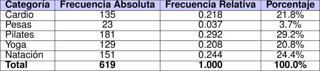

Cuatro analistas han propuesto diferentes afirmaciones sobre la interpretación de los datos de la categoría **Natación**.

**¿Cuál de las siguientes afirmaciones es CORRECTA y está BIEN JUSTIFICADA matemáticamente?**

## Answerlist

- El 24.4% de asistentes corresponde a la categoría ‘Natación’ porque la frecuencia relativa (0.244) multiplicada por 100 da como resultado 24.4%
- El 24.4% de asistentes corresponde a la categoría ‘Natación’ porque se obtiene al dividir 151 entre 619
- El 2.4% de asistentes corresponde a la categoría ‘Natación’ porque se calcula dividiendo la frecuencia absoluta entre el total
- El 24.4% de asistentes corresponde a la categoría ‘Natación’ porque representa la proporción de esa categoría respecto al total

# Solution

Para resolver este problema de **argumentación matemática**, debemos evaluar cada afirmación y determinar cuál está correctamente justificada según las propiedades de las tablas de frecuencia.

**Análisis de la categoría ‘Natación’:**

- **Frecuencia absoluta:** 151 asistentes
- **Frecuencia relativa:** 0.244
- **Porcentaje:** 24.4%

**Cálculo del porcentaje:**

El porcentaje se calcula multiplicando la frecuencia relativa por 100:

$$\text{Porcentaje} = \text{Frecuencia relativa} \times 100 = 0.244 \times
100 = 24.4\%$$

Alternativamente, se puede calcular directamente:

$$\text{Porcentaje} = \frac{\text{Frecuencia absoluta}}{\text{Total}}
\times 100 = \frac{151}{619} \times 100 = 24.4\%$$

**Evaluación de las afirmaciones:**

La afirmación correcta es: **“El 24.4% de asistentes corresponde a la categoría ‘Natación’ porque la frecuencia relativa (0.244) multiplicada por 100 da como resultado 24.4%”**

**¿Por qué es correcta?**

- Identifica correctamente el porcentaje (24.4%)
- Explica adecuadamente la relación entre frecuencia relativa y porcentaje
- La justificación matemática es precisa: frecuencia relativa × 100 = porcentaje
- Utiliza los valores correctos de la tabla

**Conceptos clave:**

- **Frecuencia absoluta:** Número de casos en cada categoría
- **Frecuencia relativa:** Proporción de casos (valor entre 0 y 1)
- **Porcentaje:** Frecuencia relativa multiplicada por 100 (valor entre 0% y 100%)
- **Relación:** Porcentaje = Frecuencia relativa × 100

# Meta-information

exname: tablas_frecuencia_argumentacion_estadistica extype: schoice exsolution: 1000 exshuffle: TRUE exsection: Estadística/Tablas de frecuencia/Argumentación